[figure not shown]

# Recommendations for QANTAS: USA airport infrastucture, and a domestic aircraft storage facility

ETC5512 Assignment 1, Master of Business Analytics

Prepared by Mohammed Faizan, 31939872, mfai0014@student.monash.edu

April 16, 2021

# Introduction

*"Every year, millions of people rely on the Qantas Group to take them somewhere.* *We’ve been serving communities for 100 years. And we know that our continued* *success relies on combining day-to-day operational excellence with scanning the* *horizon."* ~ **Qantas**[1]

*"The Qantas Group is constantly transforming to make sure we’re well positioned* *for the future. That’s how we keep creating value for our stakeholders,* *opportunities for our people and world-class experiences for our customers.* *In the process, we aim to have a positive impact on the broader community and* *minimise our impact on the natural environment. And, above all, achieve the* *highest standards of safety and integrity."* ~ **Qantas**[1]

Being commissioned as an independent Business analyst consultant for the chief data officer for Qantas*, this report apropos of analysis on the recommendation for the primary airport in the United States of America for Qantas flights into and out of USA. This report also contains recommendation on selecting a new plane storage facility - that has least impact on local endangered species, in Victoria, Australia.

# Report: Recommendation for the primary airport into and out of the USA.

*Office of Airline Information, Bureau of Transportation Statistics*, oversights data provision for the domestic flight operation in USA. Supplementary Information has the overview of the BTS Flights data. Flights relating to two airports, DFW and LAX, are analyzed based on two performance criteria for the month of January, 2020.

## Connectivity across continental USA.

Connectivity is measured by the number of airports, and their spatial distribution across continental USA, that are connected by flights(both inbound and outbound) to the airports, DFW and LAX. The first insight, was developed by preparing the data for tallying flight records for airport network and flight traffic.

Overview of the Connectivity by Numbers

| airport | to_num_airport | from_num_airport | outbound_flights | inbound_flights |
| --- | --- | --- | --- | --- |
| DFW | 177 | 177 | 24915 | 24932 |
| LAX | 92 | 94 | 18377 | 18370 |

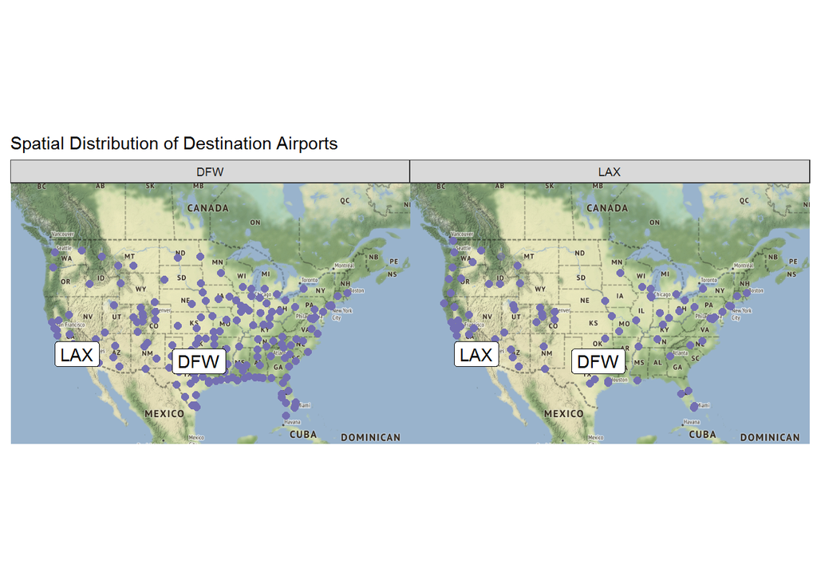

Spatial Distribution of Airports Across USA

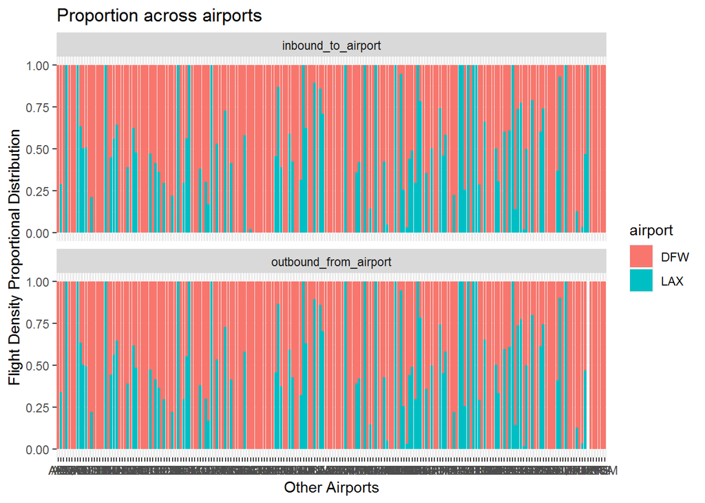

Proportion across airports

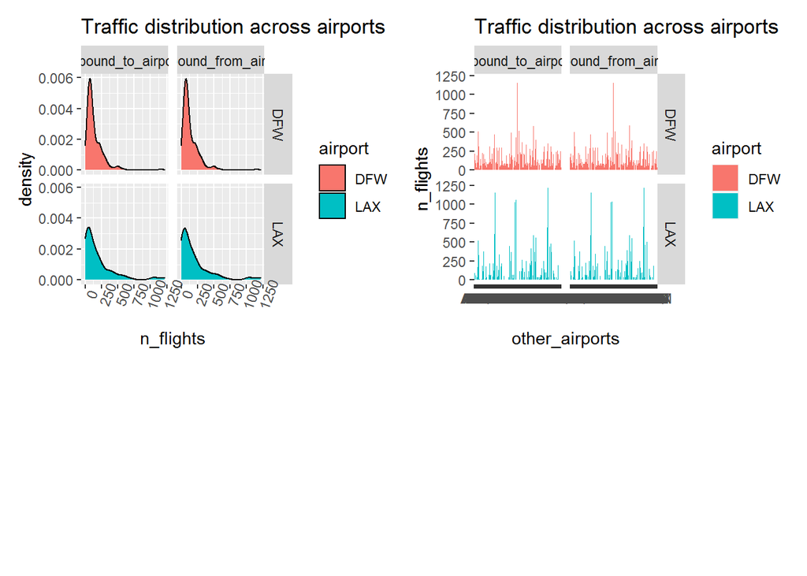

Traffic distribution across airports

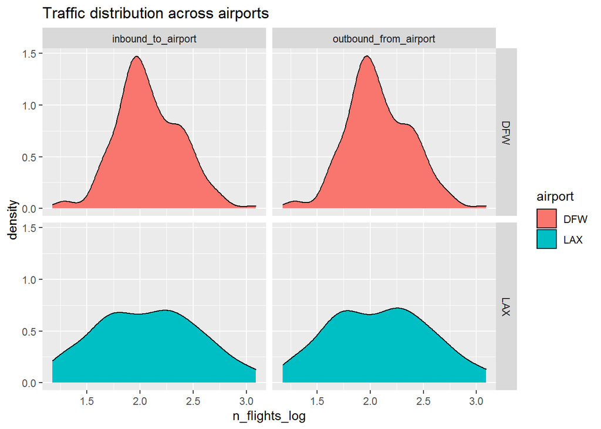

Normalising traffic distribution

## Delay in flight operation

Airport operation performance for delay in flights is best measured for an origin airport in terms of departure delay. And, for a destination airport the arrival delay must be considered. Other delays are caused by weather conditions and arrival/departure performance of the other airport and other factors. For passenger convenience, disregarding all other criteria for flight operation, flight transit time must be minimized. To accommodate maximum passengers(to include late check-in passengers) flights could depart later than the scheduled departure time and arrive faster than the scheduled arrival time( to fetch passengers some extra time). Hypothetically, a flight departing late and arriving earlier has the least transit time. However, the departure delay and the arrival delay share a linear relationship. This means if there is delay at origin, the flight is inherently late on arrival at the destination. Transit time assessment can be generalized by the following explanation and is considered to be characteristic of the flights relating to a particular airport.

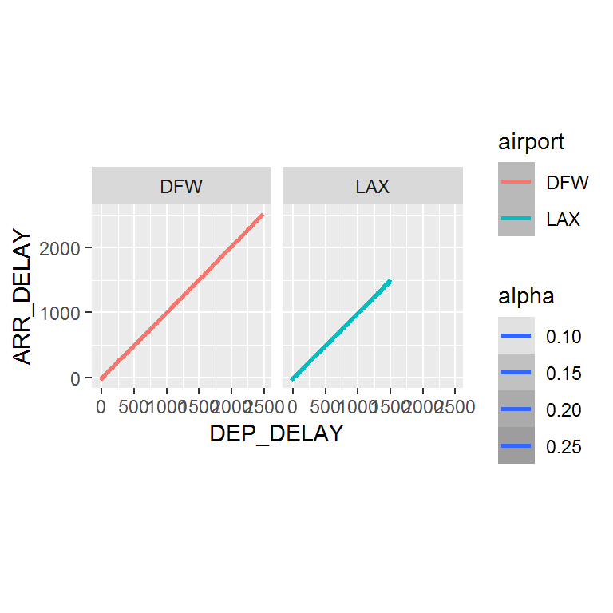

Departure Delay vs Arrival Delay

The box-plots below show the arrival and departure delays for DFW and LAX as both origin and destination. In order to reduce the transit time, a flight should not have linear arrival and departure delays. This means, when a flight has a positive departure delay, it should arrive on time or on negative arrive delay. Considering the median delay of the flights, delay statistics of that airport can be drawn. In the plot below, when DFW and LAX are the origin airports, it is observed that the departure delays of both airports are comparable. However, the arrival delay for flights originating from LAX shift downward arriving earlier than the flights originating from DFW. This pattern follows even for DFW and LAX as destination airports. Furthermore, the spread of arrival delay below median is more for LAX flights and the upper quartile of departure delay of DFW flights is high and positive which suggests that DFW flights depart late and thus arrive late. Furthermore, LAX performs better on busy days, Thursday and Friday. Thus, in comparision with DFW,in comparision with DFW, LAX is more reliable as the primary airport into and out of USA as it has more flights with arrival delays tending towards negative values(not far from 0) and fewer flights with arrival delays greater than zero.

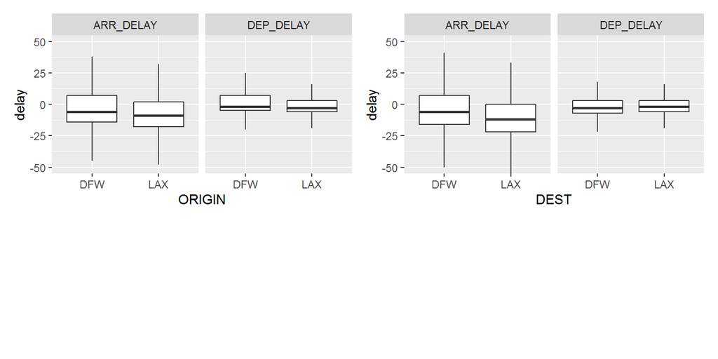

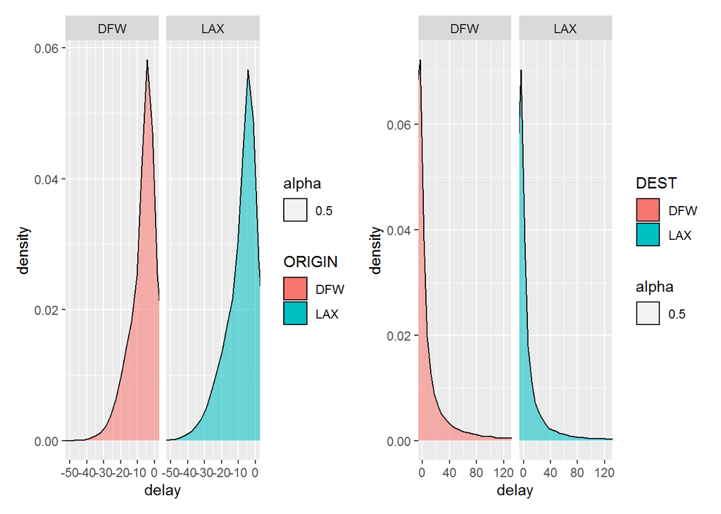

Delay distribution

| ORIGIN | DEST | delay_type | min | m10 | m1 | m2 | m3 | m90 | max | quartile_range |
| --- | --- | --- | --- | --- | --- | --- | --- | --- | --- | --- |
| DFW | NA | departure delay | -20 | -7 | -5 | -2 | 7 | 38 | 1193 | 12 |
| LAX | NA | departure delay | -26 | -8 | -6 | -3 | 3 | 23 | 1495 | 9 |
| NA | DFW | arrival delay | -80 | -23 | -16 | -6 | 7 | 36 | 2536 | 23 |
| NA | LAX | arrival delay | -96 | -32 | -22 | -12 | 0 | 20 | 1509 | 22 |
| DFW | NA | arrival delay | -75 | -20 | -14 | -6 | 7 | 37 | 1185 | 21 |
| LAX | NA | arrival delay | -63 | -25 | -18 | -9 | 2 | 21 | 1464 | 20 |
| NA | DFW | departure delay | -26 | -9 | -7 | -3 | 3 | 34 | 2489 | 10 |
| NA | LAX | departure delay | -29 | -8 | -6 | -2 | 3 | 23 | 1501 | 9 |

# Report: Recommendation on selecting new plane storage facility in Victoria, Australia.

"The Atlas of Living Australia (ALA) is a collaborative, digital, open infrastructure that pulls together Australian biodiversity data from multiple sources, making it accessible and reusable."~ ALA[2] Data was collected and records were filtered to assess the geographical area of 50km radius around Bendigo and Tullamarine each (plane storage facilities) for specific local endangered species in Victoria, Australia. The area that inhabits fewer species both in number and type is the selection criteria for the new plane storage facility. Bendigo is inhabited by only 2 species occurring and Tullamarine is inhabited by all 7 species occuring within its 50km radius over the past two decades. Of the two species, Anthochaera (Xanthomyza) phrygia and Ornithorhynchus anatinus, occurring at both locations, occurrence of Anthochaera (Xanthomyza) phrygia is comparable at both locations and Tullamarine has double the occurrences of Ornithorhynchus anatinus than Bendigo.

Occurences

| plane_storage | Scientific.Name | n_occurences |
| --- | --- | --- |
| Bendigo | Anthochaera (Xanthomyza) phrygia | 10 |
| Bendigo | Ornithorhynchus anatinus | 131 |
| Tullamarine | Anthochaera (Xanthomyza) phrygia | 11 |
| Tullamarine | Neophema (Neonanodes) chrysogaster | 93 |
| Tullamarine | Ornithorhynchus anatinus | 303 |
| Tullamarine | Perameles gunnii | 14 |
| Tullamarine | Petauroides volans | 23 |
| Tullamarine | Petrogale penicillata | 4 |
| Tullamarine | Thinornis cucullatus | 2 |

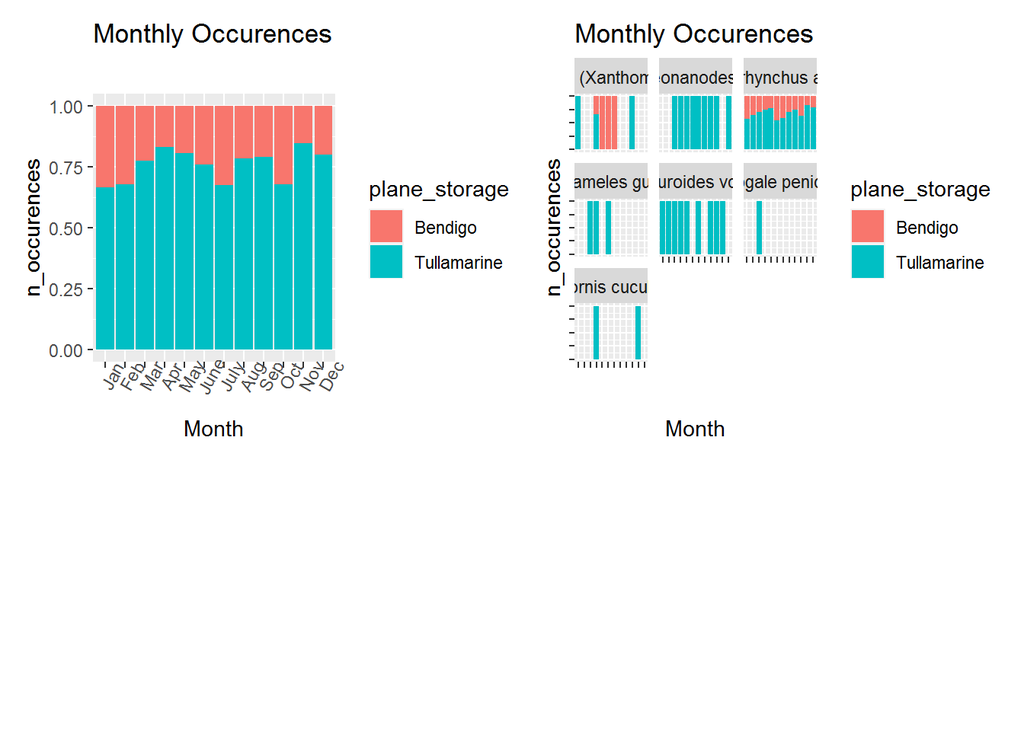

Species are termed endangered when their occurrence reduces over the years due to anthropogenic and natural influences on their existence. It is essential to lookup on these longitudinal trends to better decide the influence of the activities and climate changes in these location on the existence of such endangered species. Tullamarine has had the least impact on the occurrences as the occurrences have been increasing and decreasing in a non-general trend. However, in Bendigo the occurrences of these species have declined from 2004 onwards with no occurrence in 2012. "Ornithorhynchus anatinus" is the only species to inhabit both locations across all years. In 2020 it was the only species occurring at both locations. However, Tullamarine has more occurrences of "Ornithorhynchus anatinus" than Bendigo. Thus, Tullamarine has been inhabited by different species over two decades and presently holds a larger population of the dwelling species. Thus, Tullamarine is a more promising habitat for these endangered species in Victoria.

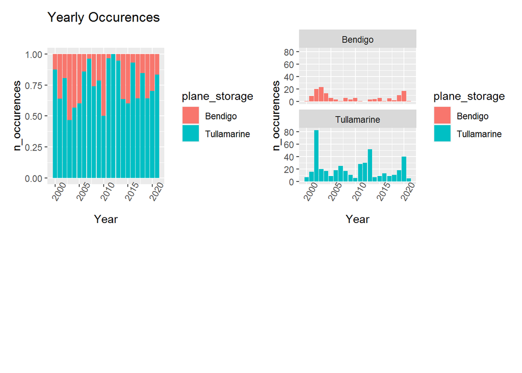

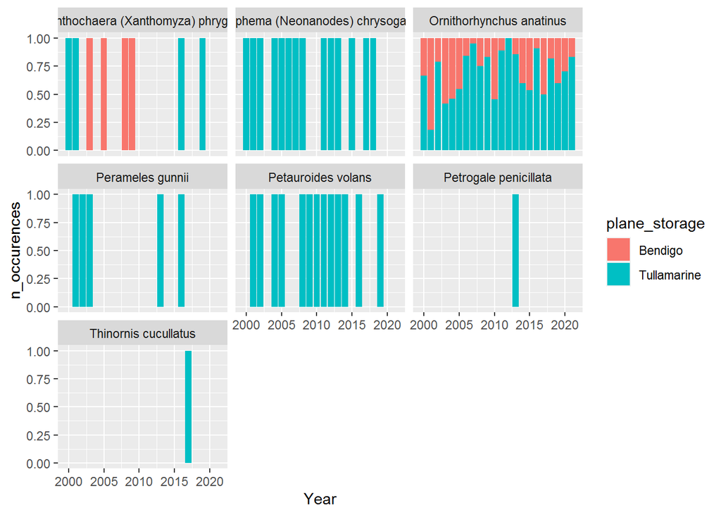

Spatial distribution of the occurrences of species is an important factor to assess the feasibility of the plane storage location such that the plane storage airport has the least impact on the existence of these endangered species. From maps below, it is observed that in Tullamarine, species occurrences span the 50km geographic area. However, in Bendigo, the endangered species population surrounds the 50km geographic area, on the circumference. Hence, the plane storage airport could be centered around these creatures having a respectable distance, thus avoiding interruptions in their natural habitat. Therefore, Tullamarine being the better habitat for these creatures and because of spatial distribution of occurrences of species in Bendigo, the latter is a better plane storage location in Victoria, Australia.

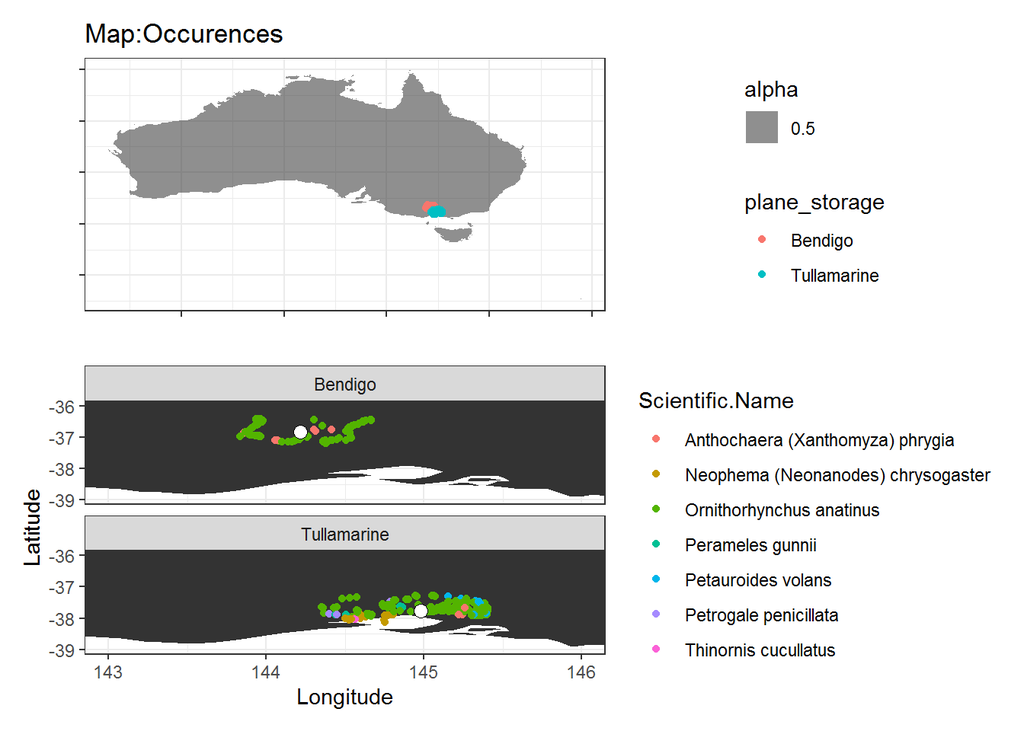

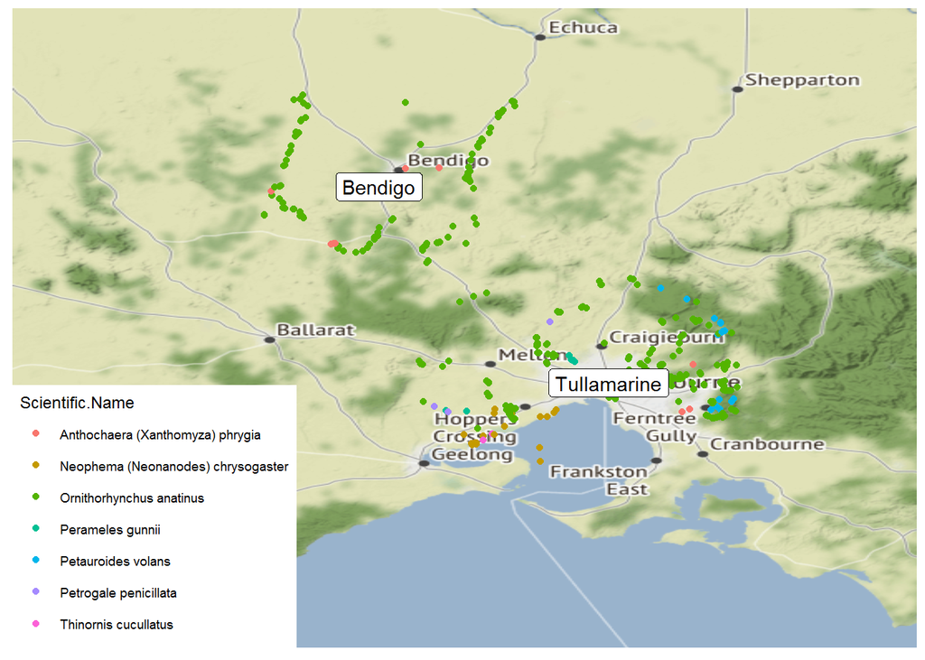

## Resources

R Core Team (2021). R: A language and environment for statistical computing. R Foundation for Statistical Computing, Vienna, Austria. URL https://www.R-project.org/.

```
## tidyverse
```

```
## @Article{,
##   title = {Welcome to the {tidyverse}},
##   author = {Hadley Wickham and Mara Averick and Jennifer Bryan and Winston Chang and Lucy D'Agostino McGowan and Romain François and Garrett Grolemund and Alex Hayes and Lionel Henry and Jim Hester and Max Kuhn and Thomas Lin Pedersen and Evan Miller and Stephan Milton Bache and Kirill Müller and…
##   year = {2019},
##   journal = {Journal of Open Source Software},
##   volume = {4},
##   number = {43},
##   pages = {1686},
##   doi = {10.21105/joss.01686},
## }
```

```
##
##
## plotly
```

```
## @Book{,
##   author = {Carson Sievert},
##   title = {Interactive Web-Based Data Visualization with R, plotly, and shiny},
##   publisher = {Chapman and Hall/CRC},
##   year = {2020},
##   isbn = {9781138331457},
##   url = {https://plotly-r.com},
## }
```

```
##
##
## visdat
```

```
## @Article{,
##   title = {visdat: Visualising Whole Data Frames},
##   author = {Nicholas Tierney},
##   doi = {10.21105/joss.00355},
##   url = {http://dx.doi.org/10.21105/joss.00355},
##   year = {2017},
##   publisher = {Journal of Open Source Software},
##   volume = {2},
##   number = {16},
##   pages = {355},
##   journal = {JOSS},
## }
```

```
##
##
## naniar
```

```
## @Manual{,
##   title = {naniar: Data Structures, Summaries, and Visualisations for Missing Data},
##   author = {Nicholas Tierney and Di Cook and Miles McBain and Colin Fay},
##   year = {2020},
##   note = {R package version 0.6.0},
##   url = {https://CRAN.R-project.org/package=naniar},
## }
```

```
##
##
## lubridate
```

```
## @Article{,
##   title = {Dates and Times Made Easy with {lubridate}},
##   author = {Garrett Grolemund and Hadley Wickham},
##   journal = {Journal of Statistical Software},
##   year = {2011},
##   volume = {40},
##   number = {3},
##   pages = {1--25},
##   url = {https://www.jstatsoft.org/v40/i03/},
## }
```

```
##
##
## geosphere
```

```
## @Manual{,
##   title = {geosphere: Spherical Trigonometry},
##   author = {Robert J. Hijmans},
##   year = {2019},
##   note = {R package version 1.5-10},
##   url = {https://CRAN.R-project.org/package=geosphere},
## }
```

```
##
##
## ggmap
```

```
## @Article{,
##   author = {David Kahle and Hadley Wickham},
##   title = {ggmap: Spatial Visualization with ggplot2},
##   journal = {The R Journal},
##   year = {2013},
##   volume = {5},
##   number = {1},
##   pages = {144--161},
##   url = {https://journal.r-project.org/archive/2013-1/kahle-wickham.pdf},
## }
```

```
##
##
## ggthemes
```

```
## @Manual{,
##   title = {ggthemes: Extra Themes, Scales and Geoms for 'ggplot2'},
##   author = {Jeffrey B. Arnold},
##   year = {2021},
##   note = {R package version 4.2.4},
##   url = {https://CRAN.R-project.org/package=ggthemes},
## }
```

```
##
##
## maps
```

```
## @Manual{,
##   title = {maps: Draw Geographical Maps},
##   author = {Original S code by Richard A. Becker and Allan R. Wilks. R version by Ray Brownrigg. Enhancements by Thomas P Minka and Alex Deckmyn.},
##   year = {2018},
##   note = {R package version 3.3.0},
##   url = {https://CRAN.R-project.org/package=maps},
## }
```

```
##
##
## bookdown
```

```
## @Manual{,
##   title = {bookdown: Authoring Books and Technical Documents with R Markdown},
##   author = {Yihui Xie},
##   year = {2020},
##   note = {R package version 0.21},
##   url = {https://github.com/rstudio/bookdown},
## }
##
## @Book{,
##   title = {bookdown: Authoring Books and Technical Documents with {R} Markdown},
##   author = {Yihui Xie},
##   publisher = {Chapman and Hall/CRC},
##   address = {Boca Raton, Florida},
##   year = {2016},
##   note = {ISBN 978-1138700109},
##   url = {https://github.com/rstudio/bookdown},
## }
```

```
##
##
## knitr
```

```
## @Manual{,
##   title = {knitr: A General-Purpose Package for Dynamic Report Generation in R},
##   author = {Yihui Xie},
##   year = {2021},
##   note = {R package version 1.31},
##   url = {https://yihui.org/knitr/},
## }
##
## @Book{,
##   title = {Dynamic Documents with {R} and knitr},
##   author = {Yihui Xie},
##   publisher = {Chapman and Hall/CRC},
##   address = {Boca Raton, Florida},
##   year = {2015},
##   edition = {2nd},
##   note = {ISBN 978-1498716963},
##   url = {https://yihui.org/knitr/},
## }
##
## @InCollection{,
##   booktitle = {Implementing Reproducible Computational Research},
##   editor = {Victoria Stodden and Friedrich Leisch and Roger D. Peng},
##   title = {knitr: A Comprehensive Tool for Reproducible Research in {R}},
##   author = {Yihui Xie},
##   publisher = {Chapman and Hall/CRC},
##   year = {2014},
##   note = {ISBN 978-1466561595},
##   url = {http://www.crcpress.com/product/isbn/9781466561595},
## }
```

```
##
##
## patchwork
```

```
## @Manual{,
##   title = {patchwork: The Composer of Plots},
##   author = {Thomas Lin Pedersen},
##   year = {2020},
##   note = {R package version 1.1.1},
##   url = {https://CRAN.R-project.org/package=patchwork},
## }
```

Data sources:

- Task 1
- Office of Airline Information | BUREAU OF TRANSPORTATION STATISTICS | U.S. Department of Transportation On-Time : Reporting Carrier On-Time Performance (1987-present) https://www.transtats.bts.gov/Fields.asp?gnoyr_VQ=FGJ
- Office of Airline Information | BUREAU OF TRANSPORTATION STATISTICS | U.S. Department of Transportation Aviation Support Tables : Master Coordinate https://www.transtats.bts.gov/Fields.asp?gnoyr_VQ=FLL
- Task 2
- Records in Bendigo:

  Atlas of Living Australia occurence download at https://doi.org/10.26197/ala.10e91470-60e9-435f-888b-2de8c72fdabe , Accessed April 2021
- Records in Tullamarine:

  Atlas of Living Australia occurence download at https://doi.org/10.26197/ala.75b2f772-82be-4a57-b812-73b4a8012b4e , Accessed April 2021

Other Resources:

[1] Qantas Group https://www.qantas.com/us/en/qantas-group.html Accessed 15 April 2021

[2] Atlas of Living Australia website at https://www.ala.org.au/about-ala Accessed 15 April 2021

[3] RStudio Cloud | Primers | Visualise Data https://rstudio.cloud/learn/primers/3

[4] RStudio Cloud | Primers | Tidy Your Data https://rstudio.cloud/learn/primers/4

[5] RStudio Cloud | Primers | Work With Data https://rstudio.cloud/learn/primers/2

[6] ETC5512: Solutions for Tutorial 4 | Di Cook https://wcd.numbat.space/tutorials/tutorial-04sol.html

[7] ETC5512: Solution for Tutorial 5 | Belinda Maher https://wcd.numbat.space/tutorials/tutorial-05sol.html

[8] RStudio Cloud | Primers | Visualise Data | Line plots and maps | Maps https://rstudio.cloud/learn/primers/3.6

- This is just a hypothetical scenario for the assignment. ETC5512: Assignment 1 | Prepared by Professor Di Cook

**Glossary**

- **DFW: Dallas/Fort Worth International**
- **LAX: Los Angeles International**

## Supplementary information

### Task1-Recommendation for the primary airport into and out of the USA.

This BTS ONTIME FLIGHTS DATA data has **18** variables and **84286** records each recording individual flights information in January 2020. The variables in the data are: **YEAR, MONTH, DAY_OF_MONTH, DAY_OF_WEEK, FL_DATE, OP_UNIQUE_CARRIER, OP_CARRIER_AIRLINE_ID, OP_CARRIER, TAIL_NUM, OP_CARRIER_FL_NUM, ORIGIN, DEST, CRS_DEP_TIME, DEP_TIME, DEP_DELAY, CRS_ARR_TIME, ARR_TIME, ARR_DELAY**

This data contains in every observation, either DFW or LAX in either ORIGIN or DEST varibales.

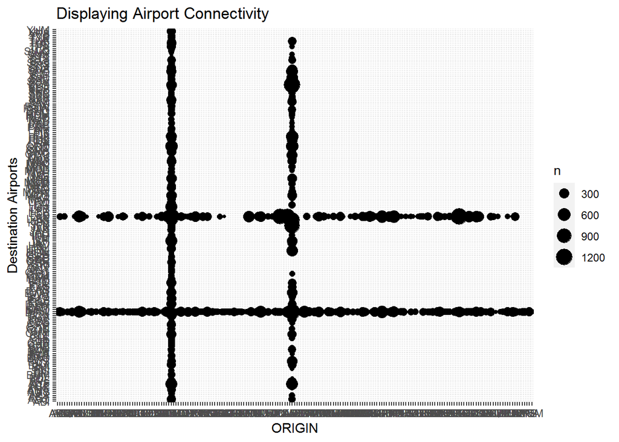

displaying airport connectivity

On plotting relation between outbound and inbound traffic, it is observed that inbound and outbound flight traffic is comparable for both DFW and LAX. Therefore, outbound traffic,in terms of numbers, is a representation of inbound traffic and vice-versa.

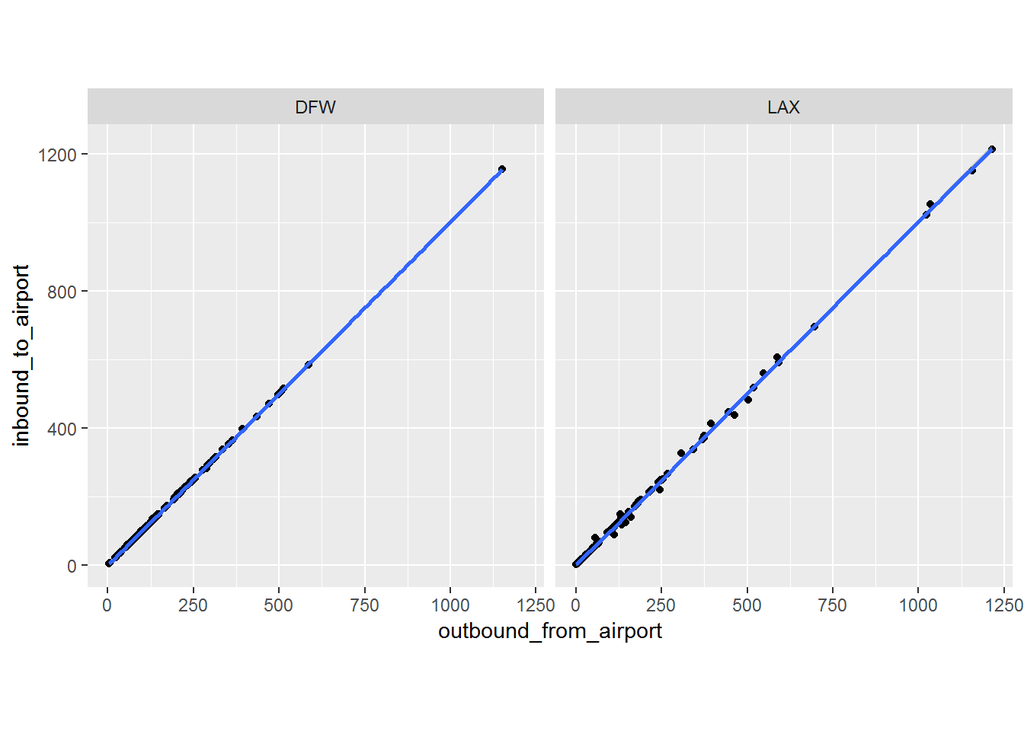

This brings us to check the connecting flights between DFW and LAX. The table below shows the top 5 airports connecting to each of the airports, DFW and LAX. It can be noted that DFW and LAX are connected well by over 1150 flights

Top 5 airports connecting to DFW and LAX

| airport | other_airports | n_flights |
| --- | --- | --- |
| DFW | LAX | 1156 |
| DFW | ORD | 584 |
| DFW | LGA | 516 |
| DFW | ATL | 508 |
| DFW | IAH | 499 |
| LAX | SFO | 1215 |
| LAX | DFW | 1152 |
| LAX | LAS | 1055 |
| LAX | JFK | 1023 |
| LAX | SEA | 696 |

Most traffic is on Thursday and Friday for both airports: DFW and LAX.

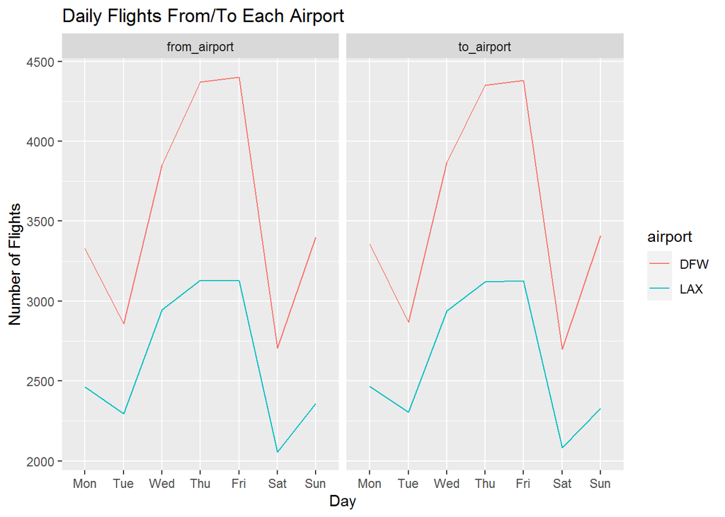

[output not shown]

LAX performs better on busy days, Thursday and Friday.

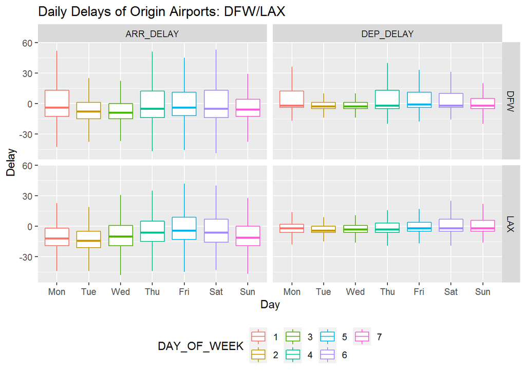

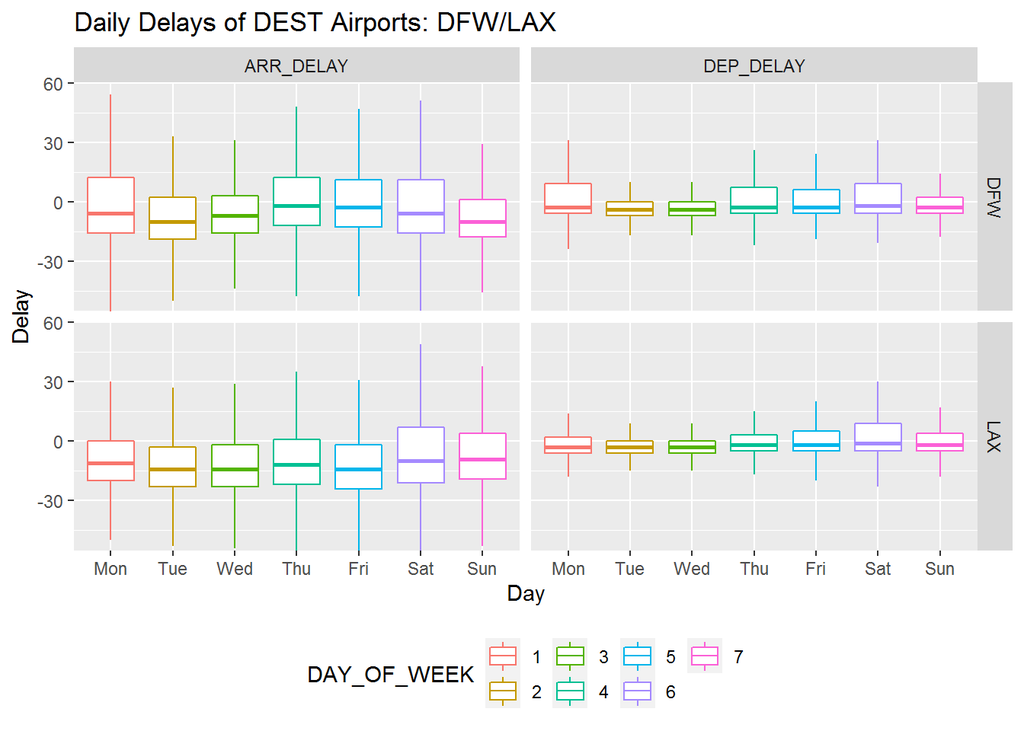

Summary of delays

Delay distribution

| ORIGIN | DEST | delay_type | min | m10 | m1 | m2 | m3 | m90 | max | quartile_range |
| --- | --- | --- | --- | --- | --- | --- | --- | --- | --- | --- |
| DFW | NA | departure delay | -20 | -7 | -5 | -2 | 7 | 38 | 1193 | 12 |
| LAX | NA | departure delay | -26 | -8 | -6 | -3 | 3 | 23 | 1495 | 9 |
| NA | DFW | arrival delay | -80 | -23 | -16 | -6 | 7 | 36 | 2536 | 23 |
| NA | LAX | arrival delay | -96 | -32 | -22 | -12 | 0 | 20 | 1509 | 22 |
| DFW | NA | arrival delay | -75 | -20 | -14 | -6 | 7 | 37 | 1185 | 21 |
| LAX | NA | arrival delay | -63 | -25 | -18 | -9 | 2 | 21 | 1464 | 20 |
| NA | DFW | departure delay | -26 | -9 | -7 | -3 | 3 | 34 | 2489 | 10 |
| NA | LAX | departure delay | -29 | -8 | -6 | -2 | 3 | 23 | 1501 | 9 |

- At 75th quartile- lax flights have lesser arrival and departure delay than dfw flights. when lax is dest, the arrival delay is 0. however, when lax and dfw are dest, they have same departure delay. Therefore LAX performs better both as origin and dest in terms of delay at 75th quartile
- At 25th quartile- the departure delays, for lax and dfw as both origin and dest, are comparable. however, lax as both origin and dest, has flights arriving faster than the dfw flights. Therefore ,LAX performs better both as origin and dest in terms of delay at 25th quartile.
- At median delay- lax flights arrive(arrival delay) much earlier than dfw flights, 3 mintues earlier when lax is origin and 6 minutes earlier for lax as dest. lax flights and dfw flights have comparable delays for departure. Therefore, LAX performs better both as origin and dest in terms of delay at median.
- At 10th percentile and 90th percentile LAX performs better than DFW following the above pattern of analysis.
- The minimum delays for DFW and LAX fall within a small range of [-96,-20] and flights associated with LAX arrive earlier.
- The maximum delays for DFW and LAX fall within a larger range of [1185,2536] and flights associated with LAX have smaller delays. The maximum delay for a DFW flight is near double to the LAX flight.

Therefore, LAX performs better than DFW in terms of delays associated with flights.

### Task2 - Recommendation on selecting new plane storage facility in Victoria, Australia.

Missingness in ALA Data

```
## [1] 0.01194102
```

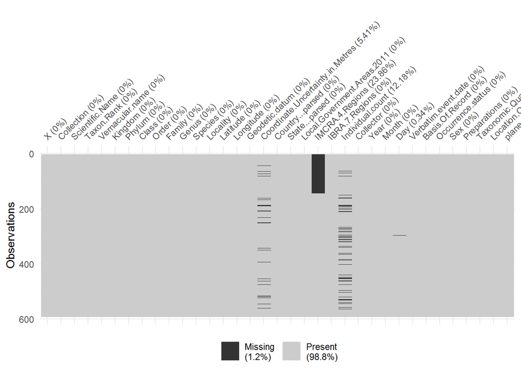

```
## # A tibble: 5 x 3
##   n_miss_in_var n_vars pct_vars
## *         <int>  <int>    <dbl>
## 1             0     31    88.6
## 2             2      1     2.86
## 3            32      1     2.86
## 4            72      1     2.86
## 5           141      1     2.86
```

```
## # A tibble: 35 x 3
##    variable                         n_miss pct_miss
##    <chr>                             <int>    <dbl>
##  1 IMCRA.4.Regions                     141   23.9
##  2 Individual.count                     72   12.2
##  3 Coordinate.Uncertainty.in.Metres     32    5.41
##  4 Day                                   2    0.338
##  5 X                                     0    0
##  6 Collection                            0    0
##  7 Scientific.Name                       0    0
##  8 Taxon.Rank                            0    0
##  9 Vernacular.name                       0    0
## 10 Kingdom                               0    0
## # ... with 25 more rows
```

occurence_summary_graph

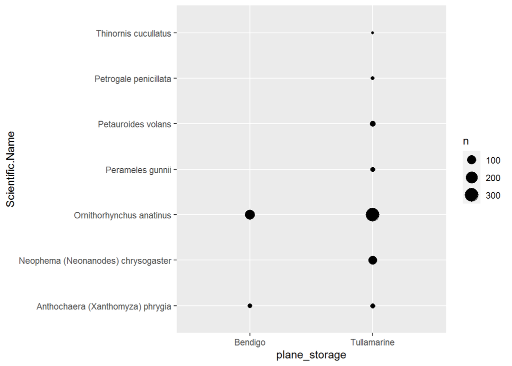

yearly occurence

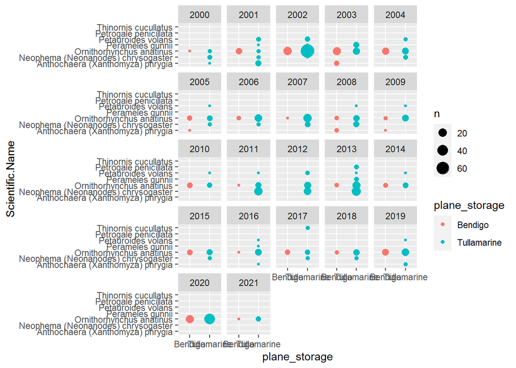